# sr_chapter_2_notes

Joseph Bulbulia

01/12/2020

# Highlights from Chapter 2 in Statistical Rethinking

A few key points in Statistical Rethinking Chapter 2

## Small worlds and large worlds

- We want to infer how the world is – the large world, however observations come from some part of that larger world
- How to build a model: in the most basic sense, we want to consider ways the world might be that are consistent with our observations. (The garden of forking data)

## Building a model for the globe toss example.

First some notation:

Some notation:

This says W is distributed N (= W + L ways) with an unknown probability p per trial that is sampled from a binomial distribution:

$W \sim Binomial(N,p)$

and we assume (here) that p is sampling from a uniform distribution (aka has a uniform range) from zero to 1, which we write as

$p \sim Uniform(0,1)$

This is how RM creates some data. Before we get started here’s a tip about how to drop scientific notation in R:

```
## [1] 0.1640625
```

```
##  [1] 0.00000000 0.05263158 0.10526316 0.15789474 0.21052632 0.26315789
##  [7] 0.31578947 0.36842105 0.42105263 0.47368421 0.52631579 0.57894737
## [13] 0.63157895 0.68421053 0.73684211 0.78947368 0.84210526 0.89473684
## [19] 0.94736842 1.00000000
```

```
##  [1] 1 1 1 1 1 1 1 1 1 1 1 1 1 1 1 1 1 1 1 1
```

```
##  [1] 0.000000000000 0.000001518149 0.000081850929 0.000777292279 0.003598575366
##  [6] 0.011160946094 0.026682986514 0.052921099148 0.090826975982 0.138341326017
## [11] 0.189768622794 0.236114658267 0.266611251684 0.271400561902 0.245005088648
## [16] 0.189768622794 0.117918117579 0.050266702076 0.008853844865 0.000000000000
```

```
##  [1] 0.000000000000 0.000001518149 0.000081850929 0.000777292279 0.003598575366
##  [6] 0.011160946094 0.026682986514 0.052921099148 0.090826975982 0.138341326017
## [11] 0.189768622794 0.236114658267 0.266611251684 0.271400561902 0.245005088648
## [16] 0.189768622794 0.117918117579 0.050266702076 0.008853844865 0.000000000000
```

```
##  [1] 0.0000000000000 0.0000007989837 0.0000430771684 0.0004090796601
##  [5] 0.0018938873153 0.0058738728763 0.0140429377069 0.0278517435944
##  [9] 0.0478011546858 0.0728073906769 0.0998729638915 0.1242643298570
## [13] 0.1403143234142 0.1428348802869 0.1289432573813 0.0998729638915
## [17] 0.0620588995470 0.0264547660594 0.0046596730033 0.0000000000000
```

We can plot this object:

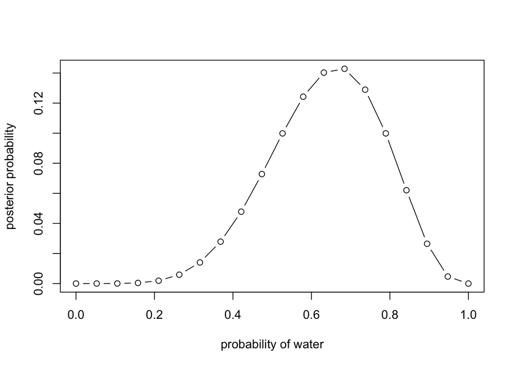

We are now in the position to change this plot by adjusting our priors:

```
##  [1] 0.0000000000000 0.0000001621311 0.0000113726966 0.0001405116112
##  [5] 0.0008463431511 0.0034151117046 0.0106224907424 0.0274099852498
##  [9] 0.0612044250533 0.1212852320186 0.1663720603822 0.1591075971600
## [13] 0.1380887886635 0.1080445007460 0.0749685321385 0.0446313771070
## [17] 0.0213161318302 0.0069842573112 0.0009455483147 0.0000000000000
```

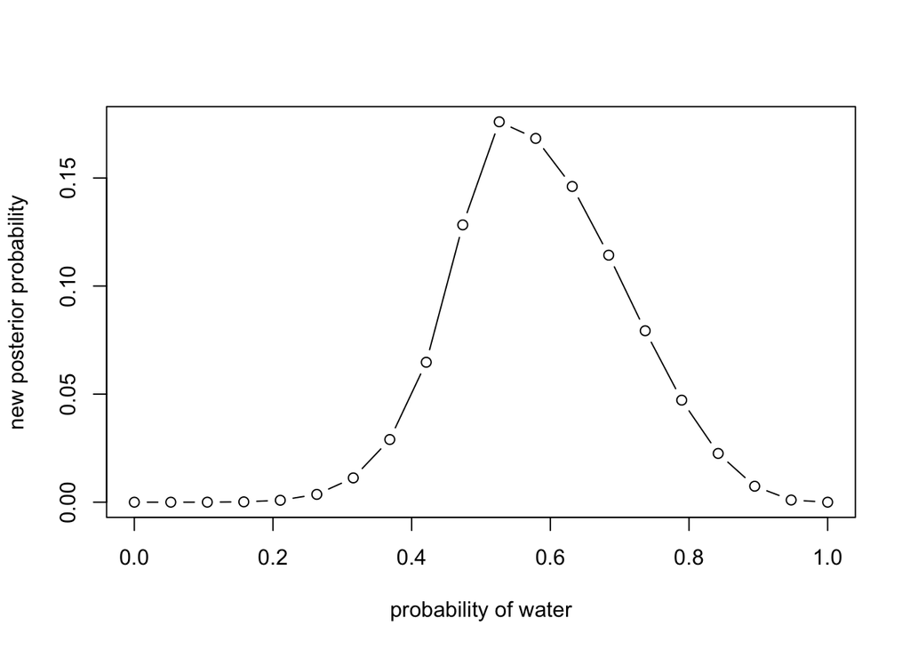

# Questions

Explain RM’s meaning here:

> It is common to hear that there is a minimum number of observations for a useful statistical estimate. For example, there is a widespread superstition that 30 observations are needed before one can use a Gaussian distribution. Why? In non-Bayesian statistical inference, procedures are often justified by the method’s behavior at very large sample sizes, so-called asymptotic behavior. As a result, performance at small samples sizes is questionable. In contrast, Bayesian estimates are valid for any sample size. This does not mean that more data isn’t helpful—it certainly is. Rather, the estimates have a clear and valid interpretation, no matter the sample size. But the price for this power is dependency upon the initial plausibilities, the prior. If the prior is a bad one, then the resulting inference will be misleading.

# Our first model using the rethinking package

```
## rstan (Version 2.21.2, GitRev: 2e1f913d3ca3)
```

[output not shown]

```
## rethinking (Version 2.13)
```

```
##        mean        sd      5.5%     94.5%
## p 0.6666666 0.1571338 0.4155365 0.9177968
```

Note: “The quadratic approximation, either with a uniform prior or with a lot of data, is often equivalent to a MAXIMUM LIKELIHOOD ESTIMATE (MLE) and its STANDARD ERROR.”

```
##        mean         sd      5.5%     94.5%
## p 0.5443747 0.08616263 0.4066701 0.6820792
```

# Practicalities (not in the book)

Solomon Kurz’s code for replicating the rethinking plots: https://bookdown.org/ajkurz/Statistical_Rethinking_recoded/small-worlds-and-large-worlds.html

Let’s use his code to run a bayesian model in brms:

[output not shown]

```
##  Family: binomial
##   Links: mu = identity
## Formula: w | trials(n) ~ 1
##    Data: list(w = w, n = n) (Number of observations: 1)
## Samples: 4 chains, each with iter = 4000; warmup = 1000; thin = 1;
##          total post-warmup samples = 12000
##
## Population-Level Effects:
##           Estimate Est.Error l-95% CI u-95% CI Rhat Bulk_ESS Tail_ESS
## Intercept     0.66      0.08     0.50     0.80 1.00     3569     4105
##
## Samples were drawn using sampling(NUTS). For each parameter, Bulk_ESS
## and Tail_ESS are effective sample size measures, and Rhat is the potential
## scale reduction factor on split chains (at convergence, Rhat = 1).
```

```
## # Fixed effects
##
## Parameter   | Median |       89% CI |   pd | % in ROPE |  Rhat |  ESS
## ---------------------------------------------------------------------
## (Intercept) |   0.66 | [0.55, 0.79] | 100% |        0% | 1.002 | 3579
```

```
## Using highest density intervals as credible intervals.
```

```
## # Fixed effects
##
## Parameter   | Median |       89% CI |   pd | % in ROPE |  Rhat |  ESS
## ---------------------------------------------------------------------
## (Intercept) |   0.66 | [0.55, 0.79] | 100% |        0% | 1.002 | 3579
```

```
## Using highest density intervals as credible intervals.
```

Here’s a some code from the Kurz boook

```
## # A tibble: 4 x 5
##     p_1   p_2   p_3   p_4   p_5
##   <dbl> <int> <int> <int> <dbl>
## 1     0     1     1     1     1
## 2     0     0     1     1     1
## 3     0     0     0     1     1
## 4     0     0     0     0     1
```

Make a plot

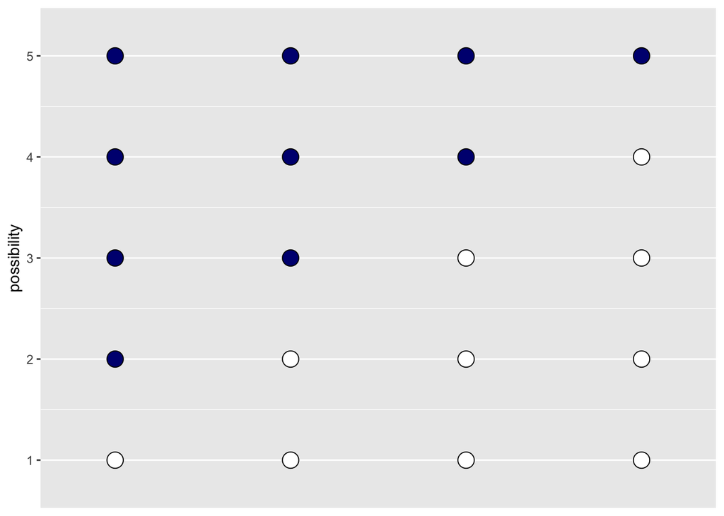

You can do the rest of the graph at your own leasure. I just wanted to show you how to make a “tibble.” Later on, methods like this will be useful for creating simulated datasets.